# 강서구_공모전

### **강서구 공모전 – 여성취업프로그램 제안**

#### 1. 여성 취업 프로그램을 기획한 이유

- 남자보다 여자의 취업율이 낮다.
  - 행정구역_시도__성별_경제활동인구 -- 전국(전체)
  - 시군구_성별_경제활동인구_총괄(2021) -- 강서구만 따로

\

#### 2. 여성들의 취업에 대한 생각?

- 여성 취업시 고려사항 변화 (2016- 2020)
- 취업희망직종 변화

\

#### 3. 현재 시행되고 있는 프로그램 현황?

- 시도별 프로그램 대상별/주제별 프로그램 수 – 2018년 자료???
- 시도별 직업훈련 프로그램들
  - 여성가족부_직업교육훈련 안내정보.csv,
  - 서울시 여성인력 개발원 교육강좌 정보(2022).xlsx) -- 워드클라우드?

\

#### 4. 강서구내 뜨는 산업 or 취업 직종

- 서울시 사업체현황 종사자수(산업대분류별 동별 성별) 통계 – 강서구 발전 산업들?
- 취업전망이 좋은 직업? – 중장기 인력수급 전망 2020-2030
- 서울시 직업유형별 취업인구(구별) 통계 – 강서구 여성 취업 직종 파악? (문제점 -> 2020, 2015, 2010 자료밖에 없음.)

\

#### 5. 프로그램 제안

- 뜨는 산업 or 직업에 관련된 취업교육프로그램
- 멘티-멘토???

### 분석절차

- 데이터준비하기(파일다운로드 및 파일 소개)
- 데이터 훑어보기
- 분석하고자 하는 내용 파악
- 데이터 전처리하기
- EDA & 시각화

seaborn 라이브러리

- [seaborn 공식 도큐먼트](https://seaborn.pydata.org/)
- [seaborn 차트종류](https://seaborn.pydata.org/api.html)

컬러팔레트

- [Seaborn의 컬러팔레트](https://chrisalbon.com/python/data_visualization/seaborn_color_palettes/)
- https://seaborn.pydata.org/tutorial/color_palettes.html

```python
#1.나눔폰트설치
!sudo apt-get install -y fonts-nanum
!sudo fc-cache -fv
!rm ~/.cache/matplotlib -rf
#2.런타임메뉴 > 런타임 다시시작
```

[output not shown]

```python
#3.같은 코드 한번 더 실행
!sudo apt-get install -y fonts-nanum
!sudo fc-cache -fv
!rm ~/.cache/matplotlib -rf
```

[output not shown]

```python
import matplotlib.pyplot as plt
import seaborn as sns

plt.rc('font', family='NanumBarunGothic')
#plt.rc('font', family='NanumGothic')
plt.rc("axes", unicode_minus=False)
```

```python
# 경고 메시지는 출력되지 않게
import warnings
warnings.filterwarnings("ignore")
```

```python
import pandas as pd
import numpy as np
```

### 1. 여성 취업 프로그램을 기획한 이유

- 남자보다 여자의 취업율이 낮다.
  - 행정구역_시도__성별_경제활동인구 -- 전국(전체)
  - 시군구_성별_경제활동인구_총괄(2021) -- 강서구만 따로

#### 전국 경제활동인구

```python
from google.colab import drive
drive.mount('/content/drive')
```

```python
filename = '/content/행정구역_시도__성별_경제활동인구_20220322095314.csv'
```

```python
#csv파일 읽어오기
df = pd.read_csv(filename, encoding='cp949')
# df = pd.read_excel(filename)  #엑셀파일
```

```python
df
```

- 데이터 훑어보기

```python
df.shape  # 크기 확인
```

```
(378, 10)
```

```python
df.isna().sum()  # 결측값 확인
```

```
시점                0
시도별               0
성별                0
15세이상인구 (천명)      0
경제활동인구 (천명)       0
비경제활동인구 (천명)      0
경제활동참가율 (%)       0
실업률 (%)           0
고용률 (%)           0
15~64세 고용률 (%)    0
dtype: int64
```

```python
df.info()  # 데이터 전체적인 파악
```

```
<class 'pandas.core.frame.DataFrame'>
RangeIndex: 378 entries, 0 to 377
Data columns (total 10 columns):
 #   Column          Non-Null Count  Dtype
---  ------          --------------  -----
 0   시점              378 non-null    float64
 1   시도별             378 non-null    object
 2   성별              378 non-null    object
 3   15세이상인구 (천명)    378 non-null    int64
 4   경제활동인구 (천명)     378 non-null    int64
 5   비경제활동인구 (천명)    378 non-null    int64
 6   경제활동참가율 (%)     378 non-null    float64
 7   실업률 (%)         378 non-null    float64
 8   고용률 (%)         378 non-null    float64
 9   15~64세 고용률 (%)  378 non-null    float64
dtypes: float64(5), int64(3), object(2)
memory usage: 29.7+ KB
```

- 데이터 전처리

```python
# '계' 요소들 제거
df1 = df[(df['성별'] != '계') & (df['시도별'] != '계')]
```

```python
# 성별 factor로 변경
df1['성별'] = df1['성별'].astype('category')
```

```python
df1['성별'].unique()
```

```
['남자', '여자']
Categories (2, object): ['남자', '여자']
```

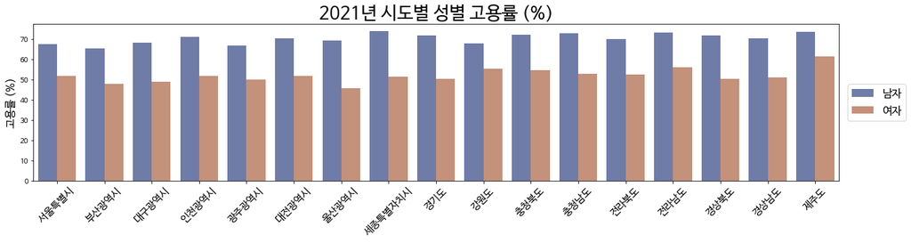

```python
fig = plt.figure(figsize = (20, 4))   # 그래프 화면 크기

g = sns.barplot(data = df1[df1['시점'] == 2021],
                x = "시도별", y = "고용률 (%)",
                hue = "성별",  # 구분
                ci = None, palette = "dark", alpha = .6)
              # 체크표시 없음, 색상 팔레트, 색상 명도

# 제목
plt.title('2021년 시도별 성별 고용률 (%)', fontsize= 25)

# 축제목
plt.xlabel('')
plt.ylabel('고용률 (%)', fontsize=15)

# x눈금 이름
plt.xticks(fontsize = 14, rotation = 45)

# 범례 위치
plt.legend(loc='center right', bbox_to_anchor=(1.09, 0.5), fontsize= 15)

plt.show()
```

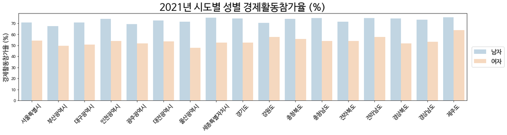

```python
# 위와 동일 코드

fig = plt.figure(figsize = (20, 4))

g = sns.barplot(data = df1[df1['시점'] == 2021],
                x="시도별", y="경제활동참가율 (%)", hue="성별",
                ci = None, alpha = .3)

plt.title('2021년 시도별 성별 경제활동참가율 (%)', fontsize=25)
plt.xlabel('')
plt.ylabel('경제활동참가율 (%)', fontsize=15)

plt.xticks(fontsize = 14, rotation = 45)
plt.legend(loc='center right', bbox_to_anchor=(1.09, 0.5), fontsize= 15)

plt.show()
```

###### 분석결과

2021년 시도별 성별 고용률과 경제활동참가율을 확인한 결과, 남자가 여자보다 고용률이 높은 걸 볼 수 있다.

#### T검정

T Score

- t-score가 크면 두 그룹이 다르다는 것을 의미한다.
- t-score가 작으면 두 그룹이 비슷하다는 것을 의미한다.

P-values

- p-value는 5%수준에서 0.05이다.
- p-values는 작은 것이 좋다. 이것은 데이터가 우연히 발생한 것이 아니라는 것을 의미한다.
- 예를 들어 p-value가 0.01 이라는 것은 결과가 우연히 나올 확률이 1%에 불과하다는 것을 의미한다.
- 대부분의 경우 0.05 (5%) 수준의 p-value를 기준으로 삼는다. 이 경우 통계적으로 유의하다고 한다.

\

결과값에서 e의 의미

```python
df_t = df[df['시도별'] == '계']
```

```python
df_t
```

```python
df_t = df_t[df_t['성별'] != '계']
```

```python
del df_t['시도별']
```

```python
df_t.columns = ['시점', '성별', '15세이상인구', '경제활동인구', '비경제활동인구',
                '경제활동참가율', '실업률', '고용률', '15~64세 고용률']
```

```python
# 성별로 데이터 나누기
m = df_t.loc[df_t['성별'] == '남자']
f = df_t.loc[df_t['성별'] == '여자']
```

- 경제활동참가율 T검정

```python
from scipy.stats import bartlett
bartlett(m['경제활동참가율'], f['경제활동참가율'])

# p값이 0.05보다 크기 때문에 등분산성이 있다고 판단 T검정 실시
# 등분산성이 없다면 ttest_ind()에는 equal_var=False 옵션을 추가
```

```
BartlettResult(statistic=2.5576939051043377, pvalue=0.10975858288344331)
```

```python
from scipy.stats import ttest_ind
ttest_ind(m['경제활동참가율'], f['경제활동참가율'])

# 귀무가설 : 성별 경제활동참가율의 평균이 차이가 없다
# 대립가설 : 성별 경제활동참가율의 평균이 차이가 있다.

# pvalue = 1.0477592183837652e-16
# p값이 0.05보다 작기 때문에 귀무가설 기각, 대립가설 채택
# 즉, 남자 고용률이 여자의 고용률보다 차이가 있다.

# e-16 = 10의 -16제곱 (즉, 자릿수)
# 예를 들어 1e-3 = 0.001
# 6.746e-16 = 0.000000000000006746
```

```
Ttest_indResult(statistic=65.5817542973845, pvalue=1.0477592183837652e-16)
```

```python
m['경제활동참가율'].mean() - f['경제활동참가율'].mean()  # 20.042857142857144 정도의 차이를 보인다.
```

```
20.042857142857144
```

- 고용률 T검정

```python
print(bartlett(m['고용률'], f['고용률']))
# pvalue=0.8705811383162056
# p값이 0.05보다 크기 때문에 등분산성이 있다고 판단

print(ttest_ind(m['고용률'], f['고용률']))
# pvalue=1.3562317002581606e-16
# T검정 결과, p값이 0.05보다 작기 때문에 귀무가설 기각, 대립가설 채택
# 귀무가설 : 성별 고용률 평균의 차이가 없다.
# 대립가설 : 성별 고용률 평균의 차이가 있다.
# p값이 0.05보다 작기 때문에 두 집단 간의 평균이 통계적으로 유의미한 차이가 존재한다.

m['고용률'].mean() - f['고용률'].mean()   # 19.414285714285725 정도의 차이가 존재.
```

```
BartlettResult(statistic=0.026543044416978474, pvalue=0.8705811383162056)
Ttest_indResult(statistic=64.18284174700568, pvalue=1.3562317002581606e-16)
```

```
19.414285714285725
```

- 15~64세 고용률 T검정

```python
print(bartlett(m['15~64세 고용률'], f['15~64세 고용률']))
# pvalue=0.3971172130623736
# p값이 0.05보다 크기 때문에 등분산성이 있다고 판단

print(ttest_ind(m['15~64세 고용률'], f['15~64세 고용률']))
# pvalue=7.350477590670831e-16
# T검정 결과, p값이 0.05보다 작기 때문에 귀무가설 기각, 대립가설 채택
# 귀무가설 : 성별 15~64세 고용률 평균의 차이가 없다.
# 대립가설 : 성별 15~64세 고용률 평균의 차이가 있다.
# p값이 0.05보다 작기 때문에 두 집단 간의 평균이 통계적으로 유의미한 차이가 존재한다.

m['15~64세 고용률'].mean() - f['15~64세 고용률'].mean()   # 18.042857142857137 정도의 차이가 존재.
```

```
BartlettResult(statistic=0.717038023731975, pvalue=0.3971172130623736)
Ttest_indResult(statistic=55.72661436284486, pvalue=7.350477590670831e-16)
```

```
18.042857142857137
```

- 실업률 T검정?

```python
print(bartlett(m['실업률'], f['실업률']))
# pvalue=0.17677337548837152
# p값이 0.05보다 크기 때문에 등분산성이 있다고 판단

print(ttest_ind(m['실업률'], f['실업률']))
# pvalue=0.39021599306449295
# T검정 결과, p값이 0.05보다 크기 때문에 귀무가설 채택, 대립가설 기각
# 귀무가설 : 성별 실업률 평균의 차이가 없다.
# 대립가설 : 성별 실업률 평균의 차이가 있다.
# p값이 0.05보다 크기 때문에 두 집단 간의 평균이 통계적으로 유의미한 차이가 존재하지 않음.

m['실업률'].mean() - f['실업률'].mean()   # -0.1857142857142855
```

```
BartlettResult(statistic=1.8245437234354367, pvalue=0.17677337548837152)
Ttest_indResult(statistic=-0.8914431257208631, pvalue=0.39021599306449295)
```

```
-0.1857142857142855
```

###### T 검정의 시각화? : 상자그림으로 표현

```python
# %단위 컬럼들
df_b = df_t.iloc[:, [0, 1, 5, 7, 8]]
```

```python
df_b
```

```python
# 데이터 행렬바꾸기 (R에서의 reshape2 패키지와 동일)
df_b = pd.melt(df_b, id_vars = ['시점', '성별'])
```

```python
df_b.columns = ['시점', '성별', '구분', '값']
```

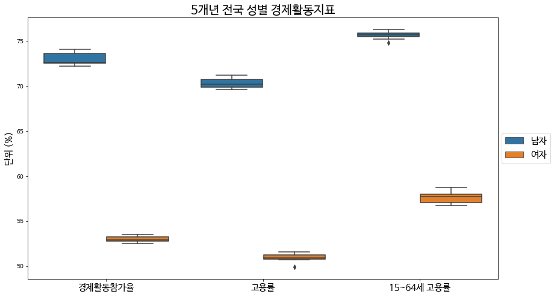

```python
fig = plt.figure(figsize = (14, 8))

g = sns.boxplot(data = df_b, x = '구분', y = '값', hue = '성별')

plt.title('5개년 전국 성별 경제활동지표', fontsize=20)
plt.xlabel('')
plt.ylabel('단위 (%)', fontsize=15)

plt.xticks(fontsize = 15)
plt.legend(loc='center right', bbox_to_anchor=(1.12, 0.5), fontsize= 15)

plt.show()
```

###### 분석결과

1. 남/여 경제활동참가율 T검정
   - 귀무가설 : 성별 경제활동참가율의 평균이 차이가 없다
   - 대립가설 : 성별 경제활동참가율의 평균이 차이가 있다.
   - **pvalue = 1.0477592183837652e-16**
   - p값이 0.05보다 작기 때문에 귀무가설 기각, 대립가설 채택
   - p값이 0.05보다 작기 때문에 두 집단 간의 평균이 통계적으로 유의미한 차이가 존재한다.
   - **즉, 남자 경제활동참가율이 여자의 경제활동참가율보다 20.04%정도 높다.**

\

1. 남/여 고용률 T검정
   - 귀무가설 : 성별 고용률 평균의 차이가 없다.
   - 대립가설 : 성별 고용률 평균의 차이가 있다.
   - **pvalue=1.3562317002581606e-16**
   - T검정 결과, p값이 0.05보다 작기 때문에 귀무가설 기각, 대립가설 채택
   - p값이 0.05보다 작기 때문에 두 집단 간의 평균이 통계적으로 유의미한 차이가 존재한다.
   - **즉, 남자 고용률이 여자의 고용률보다 19.41% 정도 높다.**

\

1. 남/여 15세~64세 고용률 T검정
   - **pvalue=7.350477590670831e-16**
   - T검정 결과, p값이 0.05보다 작기 때문에 귀무가설 기각, 대립가설 채택
   - 귀무가설 : 성별 15~64세 고용률 평균의 차이가 없다.
   - 대립가설 : 성별 15~64세 고용률 평균의 차이가 있다.
   - p값이 0.05보다 작기 때문에 두 집단 간의 평균이 통계적으로 유의미한 차이가 존재한다.
   - **즉, 15세 ~ 64세에서의 남자 고용률이 여자의 고용률보다 18.04% 정도 높다.**

\

1. 상자그림 결과
   - 전체적으로 남자와 여자와의 차이가 뚜렷하게 보인다.

#### 강서구 내 경제활동참가율

```python
filename = '/content/시군구_성별_경제활동인구_총괄_20220317172128.csv'
```

```python
#csv파일 읽어오기
df2 = pd.read_csv(filename, encoding='cp949')
# df = pd.read_excel(filename)  #엑셀파일
```

```python
df2
```

- 데이터 파악 및 전처리

```python
df2.shape  # 크기 확인
```

```
(6, 10)
```

```python
df2.isna().sum()  # 결측값 확인
```

```
시기                0
행정구역별             0
성별                0
15세이상인구 (천명)      0
경제활동인구 (천명)       0
취업자 (천명)          0
비경제활동인구 (천명)      0
경제활동참가율 (％)       0
고용률 (%)           0
15~64세 고용률 (%)    0
dtype: int64
```

```python
df2.info()  # 데이터 전체적인 파악
```

```
<class 'pandas.core.frame.DataFrame'>
RangeIndex: 6 entries, 0 to 5
Data columns (total 10 columns):
 #   Column          Non-Null Count  Dtype
---  ------          --------------  -----
 0   시기              6 non-null      object
 1   행정구역별           6 non-null      object
 2   성별              6 non-null      object
 3   15세이상인구 (천명)    6 non-null      float64
 4   경제활동인구 (천명)     6 non-null      float64
 5   취업자 (천명)        6 non-null      float64
 6   비경제활동인구 (천명)    6 non-null      float64
 7   경제활동참가율 (％)     6 non-null      float64
 8   고용률 (%)         6 non-null      float64
 9   15~64세 고용률 (%)  6 non-null      float64
dtypes: float64(7), object(3)
memory usage: 608.0+ bytes
```

```python
df2.columns = ['시기', '행정구역별', '성별', '15세이상인구', '경제활동인구', '취업자', '비경제활동인구',
              '경제활동참가율', '고용률', '15~64세 고용률']
```

```python
# '계' 요소들 제거
df2 = df2[df2['성별'] != '계']

# 행정구역별명(강서구 데이터만 존재) 제거
del df2['행정구역별']
```

```python
# 성별 factor로 변경
df2['성별'] = df2['성별'].astype('category')
# warning 이나 뭐라고 떠도 빨간색이 뜨지 않으면 실행된 것.
# .loc 구문을 쓰라는 제안일 뿐 실행되지 않은 건 아니다.
```

```python
df2['성별'].unique()
```

```
['남자', '여자']
Categories (2, object): ['남자', '여자']
```

```python
# 데이터 나누기
# 1. 천 명 단위 컬럼들
df_1000 = df2.iloc[:, :6]

# 2. %단위 컬럼들
df_p = df2.iloc[:, [0, 1, 6, 7, 8]]
```

```python
# 데이터 행렬바꾸기 (R에서의 reshape2 패키지와 동일)
df_p = pd.melt(df_p, id_vars = ['시기', '성별'])
```

```python
df_p.columns = ['시기', '성별', '구분', '값']
```

```python
df_p['시기'].unique()
```

```
array(['2021.1/2', '2021.2/2'], dtype=object)
```

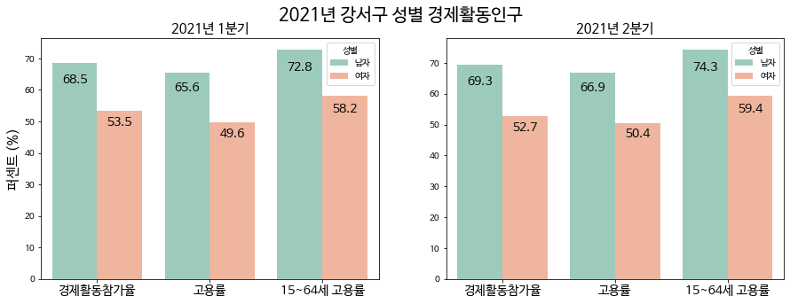

```python
fig = plt.figure(figsize = (15, 5))

# 전체 타이틀
fig.suptitle('2021년 강서구 성별 경제활동인구', fontsize = 20)

# 왼쪽 그래프 그리기
ax = plt.subplot(1, 2, 1)  # 그래프 양쪽으로 나누기
g = sns.barplot(data = df_p[df_p['시기'] == '2021.1/2'],   # 2021년 1분기 잘라 가져오기
                x = '구분', y = "값", hue = "성별",
                ci = None, palette='Set2', alpha = .7)

plt.title('2021년 1분기', fontsize=15)
plt.xlabel('')
plt.ylabel('퍼센트 (%)', fontsize=15)
plt.xticks(fontsize = 14)

# 값 가져와서 -> 텍스트 추가하기
for p in ax.patches:
    ax.text(p.get_x() + (p.get_width()/2) ,   # 가로 위치
            p.get_y() + p.get_height()/11*10,   # 세로 위치
            f"{p.get_height():.1f}",     # 값 + 표시방법 소수 둘째자리까지
            ha = 'center',  # 좌우정렬 중간으로
            fontsize=14)  # 글자 크기



# 오른쪽 그래프 그리기
ax = plt.subplot(1, 2, 2)  # 행, 열, 그래프 위치
g = sns.barplot(data = df_p[df_p['시기'] == '2021.2/2'],  # 2021년 2분기 잘라 가져오기
                x = '구분', y = "값", hue = "성별",
                ci = None, palette='Set2', alpha = .7)

plt.title('2021년 2분기', fontsize=15)
plt.xlabel('')
plt.ylabel('')

plt.xticks(fontsize = 14)
#plt.legend(loc='center right', bbox_to_anchor=(1.09, 0.5), fontsize= 15)


# 값 가져와서 -> 텍스트 추가하기
for p in ax.patches:
    ax.text(p.get_x() + (p.get_width()/2) ,   # 가로 위치
            p.get_y() + p.get_height()/11*10,   # 세로 위치
            f"{p.get_height():.1f}",     # 값 + 표시방법 소수 둘째자리까지
            ha = 'center',  # 좌우정렬 중간으로
            fontsize=14)  # 글자 크기


plt.show()
```

##### 분석결과

\

1. 2021년 2분기
   - 경제활동참가율은 남자가 여자보다 **16.6%** 더 높다
   - 고용률은 남자가 여자보다 **약 16.5%** 더 높다
   - 15 ~ 64세 고용률은 남자가 **14.9%** 더 높다.

\

- 2021년 1분기와 마찬가지로 2분기에서도 전체적으로 남자가 여자보다 높은 비율을 보인다.
- 그리고 1분기보다 2분기에서 차이가 좀더 벌어진 것을 확인할 수 있다.

#### 강서구 내 성별 취업자 수?

```python
# factor 형으로 변환
df2['시기'] = df2['시기'].astype('category')

# 시기의 값을 2021년 ..분기로 바꾸기
df2['시기'].cat.categories = ['2021년 1분기', '2021년 2분기']
```

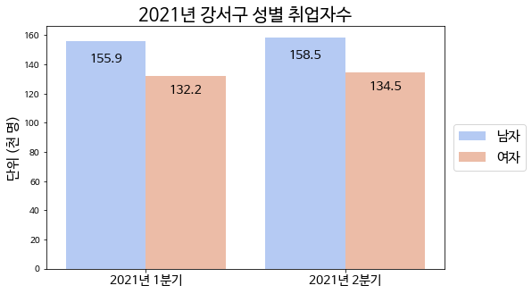

```python
# 글자를 가져오기 위해 사이즈 지정을 subplot으로 했음.
fig, ax = plt.subplots( figsize=(8,5) )

g = sns.barplot(data = df2,
                x = '시기', y = "취업자", hue = "성별",
                ci = None, palette='coolwarm')

plt.title('2021년 강서구 성별 취업자수', fontsize = 20)
plt.xlabel('')
plt.ylabel('단위 (천 명)', fontsize=15)
plt.xticks(fontsize = 14)
plt.legend(loc='center right', bbox_to_anchor=(1.22, 0.5), fontsize= 15)

# 값 가져와서 -> 텍스트 추가하기
for p in ax.patches:
    ax.text(p.get_x() + (p.get_width()/2) ,   # 가로 위치
            p.get_y() + p.get_height()/11*10,   # 세로 위치
            f"{p.get_height():.1f}",     # 값 + 표시방법 소수 둘째자리까지
            ha = 'center',  # 좌우정렬 중간으로
            fontsize=14)  # 글자 크기
```

##### 분석결과

- 2021년 강서구 취업자수를 살펴보면, 남자 여자보다 **1분기에는 2만 3천명, 2분기에는 2만 4천 명**정도 더 많이 취업된 것을 알 수 있다.

### 2. 여성들의 취업에 대한 생각?

- 여성 취업시 고려사항 변화 (2016- 2020)
- 취업희망직종 변화

#### 여성 취업시 고려사항

```python
filename = '/content/취업시_주요_고려사항_20220317171354.csv'
```

```python
#csv파일 읽어오기
df3 = pd.read_csv(filename, encoding='cp949')
# df = pd.read_excel(filename)  #엑셀파일
```

```python
df3.shape  # 크기 확인
```

```
(18, 7)
```

```python
df3.isna().sum()  # 결측값 확인
```

```
성별             0
취업시 주요 고려사항    0
2016.08        0
2018.08        0
2019.08        0
2020.08        0
2021.08        0
dtype: int64
```

```python
df3.info()  # 데이터 전체적인 파악
```

[output not shown]

```python
# 컬럼명 변경
df3.columns = ['성별', '취업시 주요 고려사항', '2016년', '2018년', '2019년', '2020년', '2021년']
```

```python
# 결측값 0으로 변경
df3['2016년'] = df3['2016년'].str.replace('-', '0')
df3['2020년'] = df3['2020년'].str.replace('-', '0')
df3['2021년'] = df3['2021년'].str.replace('-', '0')
```

```python
# 연도 컬럼 중에서 문자열 정수(int)로 변경 (astype)
df3['2016년'] = df3['2016년'].astype(int)
df3['2020년'] = df3['2020년'].astype(int)
df3['2021년'] = df3['2021년'].astype(int)
```

```python
df3.head()
```

|  | 성별 | 취업시 주요 고려사항 | 2016년 | 2018년 | 2019년 | 2020년 | 2021년 |
| --- | --- | --- | --- | --- | --- | --- | --- |
| 0 | 계 | 계 | 2342 | 1767 | 2166 | 2356 | 2508 |
| 1 | 계 | 수입, 임금수준 | 591 | 468 | 564 | 604 | 638 |
| 2 | 계 | 자신의 적성 및 전공 | 669 | 524 | 537 | 577 | 545 |
| 3 | 계 | 일자리의 안정성 및 사업체 규모 | 461 | 377 | 460 | 514 | 614 |
| 4 | 계 | 근무여건(근무시간?장소 유연성, 근무지역 등) | 622 | 396 | 604 | 660 | 710 |

```python
# 취업시 주요 고려사항에서 '?'를 ','로 변경
df3['취업시 주요 고려사항'] = df3['취업시 주요 고려사항'].str.replace('?', ', ')
```

```python
# 정규화를 위해 값들을 계에서 나누는 함수 만들기
def per(col):
    return col[1:] / col[0] * 100
```

```python
# apply함수로 반복적으로 함수 실행
# 데이터.apply(함수, axis = 0(열) or 1(행))
# axis = 0  # 컬럼별로 함수실행

df3.iloc[:, 2:] = df3.iloc[:, 2:].apply(per, axis = 0)
```

```python
# 데이터 행렬바꾸기 (R에서의 reshape2 패키지와 동일)
df3 = pd.melt(df3, id_vars = ['성별', '취업시 주요 고려사항'])
```

```python
df3.columns = ['성별', '취업시 주요 고려사항', '연도', '값']
```

```python
df3['연도'].unique()
```

```
array(['2016년', '2018년', '2019년', '2020년', '2021년'], dtype=object)
```

```python
# 계가 있는 행 빼고 데이터 만들기
df3 = df3[df3['취업시 주요 고려사항'] != '계']
```

- 시각화

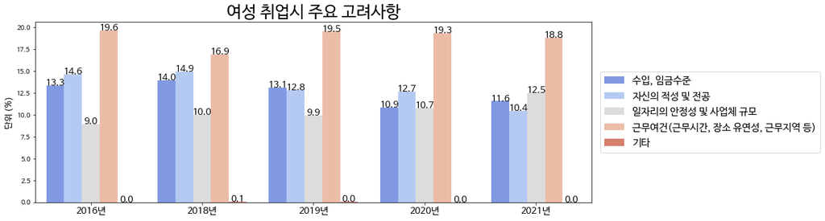

```python
# 글자를 가져오기 위해 사이즈 지정을 subplot으로 했음.
fig, ax = plt.subplots( figsize=(15,5) )

g = sns.barplot(x = '연도', y = '값', hue = '취업시 주요 고려사항',  # hue = 구분  (R에서 fill 느낌?)
                data = df3[df3['성별'] == '여자'],    # 여자 데이터만 가지고 만들기
                ci = None, palette='coolwarm')
# 제목
plt.title('여성 취업시 주요 고려사항', fontsize = 25)

# 축명
plt.xlabel('')
plt.ylabel('단위 (%)', fontsize = 13)

# x축 눈금명
plt.xticks(fontsize = 14)

# 범례 표시
plt.legend(loc='center right', bbox_to_anchor=(1.42, 0.5), fontsize= 15)

# 값 가져와서 -> 텍스트 추가하기
for p in ax.patches:
    ax.text(p.get_x() + (p.get_width()/2) ,   # 가로 위치
            p.get_y() + p.get_height(),   # 세로 위치
            round(p.get_height(), 1),     # 값 + 표시방법 - 소수 2번째 자리에서 반올림
            ha = 'center',  # 좌우정렬 중간으로
            fontsize=14)  # 글자 크기
```

#### 여성 취업 희망직업

```python
filename = '/content/취업_희망_직업_20220317171348.csv'
```

```python
#csv파일 읽어오기
df4 = pd.read_csv(filename, encoding='cp949')
# df = pd.read_excel(filename)  #엑셀파일
```

```python
df4.shape  # 크기 확인
```

```
(21, 7)
```

```python
df4.isna().sum()  # 결측값 확인
```

```python
df4.info()  # 데이터 전체적인 파악
```

```python
# 계 제거
df4 = df4[(df4['성별'] != '계') & (df4['직업별'] != '계')]
```

```python
# ? 제거
df4['직업별'] = df4['직업별'].str.replace(pat=r'[^\w]', repl=r' ', regex=True)
```

```python
df4
```

```python
# 성별 factor로 변경
df4['성별'] = df4['성별'].astype('category')
```

```python
df4['성별'].unique()
```

```
['남자', '여자']
Categories (2, object): ['남자', '여자']
```

```python
# 성별 데이터 나누기
df_m = df4.iloc[:6,:7]
df_m

df_f = df4.iloc[6:,:7]
df_f
```

```python
# 데이터 melt
df_1 = pd.melt(df_f,id_vars=['성별','직업별'])
df_1
```

```python
# 컬럼명 변경
df_1.rename(columns = {'variable':'시기'}, inplace=True)
```

```python
df_1['시기'] = df_1['시기'].astype('category')
```

```python
df_1['시기'].unique()
```

```
['2016.08', '2018.08', '2019.08', '2020.08', '2021.08']
Categories (5, object): ['2016.08', '2018.08', '2019.08', '2020.08', '2021.08']
```

```python
# 시기의 값들을 년도로 바꾸기
df_1['시기'].cat.categories = ['2016년', '2018년', '2019년', '2020년', '2021년']
```

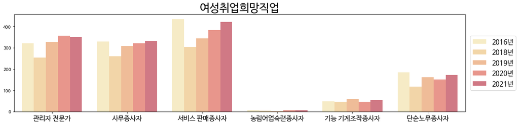

```python
fig = plt.figure(figsize = (18, 4))   # 그래프 화면 크기

#g = sns.barplot(data = df_1,
                #x = "시기", y = "value",
                #hue = "직업별",  # 구분
                #ci = None, palette = "dark", alpha = .6)
              # 체크표시 없음, 색상 팔레트, 색상 명도


g = sns.barplot(data = df_1,
                x = "직업별", y = "value",
                hue = "시기",  # 구분
                ci = None, palette = "YlOrRd", alpha = .6)

# 제목
plt.title('여성취업희망직업', fontsize= 25)

# 축제목
plt.xlabel('')
plt.ylabel('', fontsize=15)

# x눈금 이름
plt.xticks(fontsize = 15)

# 범례 위치
plt.legend(loc='center right', bbox_to_anchor=(1.12, 0.5), fontsize= 15)

plt.show()
```

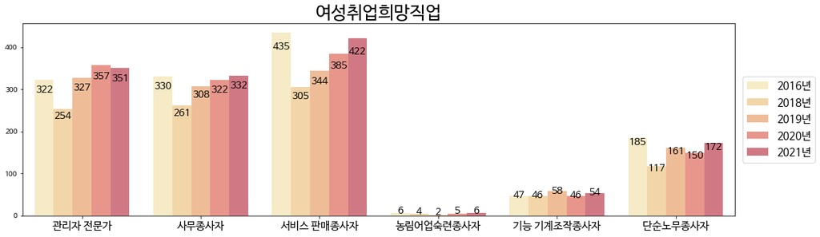

```python
# 값을 가져오기 위해 subplots를 사용하여 ax 변수 지정
fig, ax = plt.subplots(figsize = (18, 5))   # 그래프 화면 크기

#g = sns.barplot(data = df_1,
                #x = "시기", y = "value",
                #hue = "직업별",  # 구분
                #ci = None, palette = "dark", alpha = .6)
              # 체크표시 없음, 색상 팔레트, 색상 명도


g = sns.barplot(data = df_1,
                x = "직업별", y = "value",
                hue = "시기",  # 구분
                ci = None, palette = "YlOrRd", alpha = .6)

# 제목
plt.title('여성취업희망직업', fontsize= 25)

# 축제목
plt.xlabel('')
plt.ylabel('', fontsize=15)

# x눈금 이름
plt.xticks(fontsize = 15)

# 범례 위치
plt.legend(loc='center right', bbox_to_anchor=(1.12, 0.5), fontsize= 15)


# 값 가져와서 -> 텍스트 추가하기
# 그래프에서 직접 세로길이를 재서 값을 가져옴
for p in ax.patches:
    ax.text(p.get_x() + (p.get_width()/2) ,   # 가로 위치
            p.get_y() + p.get_height()/11*10,   # 세로 위치
            round(p.get_height()),     # 값 + 표시방법 소수 둘째자리까지
            ha = 'center',  # 좌우정렬 중간으로
            fontsize=14)  # 글자 크기

plt.show()
```

### 3. 현재 시행되고 있는 프로그램 현황?

- 시도별 프로그램 대상별/주제별 프로그램 수 – 2018년 자료???
- 시도별 직업훈련 프로그램들
  - 여성가족부_직업교육훈련 안내정보.csv,
  - 서울시 여성인력 개발원 교육강좌 정보(2022).xlsx) -- 워드클라우드?

#### 서울시 여성인력개발원 교육강좌 정보(2022)

```python
filename = '/content/서울시 여성인력 개발원 교육강좌 정보(2022).xlsx'
```

```python
#csv파일 읽어오기
# df = pd.read_csv(filename, encoding='cp949')
df5 = pd.read_excel(filename)  #엑셀파일
```

```python
df5.shape  # 크기 확인
```

```
(781, 27)
```

```python
df5[['강좌명']].isna().sum()  # 결측값 확인
```

```
강좌명    0
dtype: int64
```

```python
df5[['강좌명']].info()  # 데이터 전체적인 파악
```

```
<class 'pandas.core.frame.DataFrame'>
RangeIndex: 781 entries, 0 to 780
Data columns (total 1 columns):
 #   Column  Non-Null Count  Dtype
---  ------  --------------  -----
 0   강좌명     781 non-null    object
dtypes: object(1)
memory usage: 6.2+ KB
```

###### Konlp 설치

```python
!python -m pip install --upgrade konlpy
# KoNLPy는 한국어 형태소 분석 패키지
```

```
     |████████████████████████████████| 19.4 MB 1.2 MB/s
     |████████████████████████████████| 448 kB 38.7 MB/s
```

###### 텍스트 분석

```python
classname_all=''
for i in range(len(df5['강좌명'])):
    classname_all= classname_all+' '+df5['강좌명'].loc[i]
```

```python
import re
classname_all = re.sub('[^ ㄱ-ㅣ가-힣]'," ",classname_all)
classname_all
```

```
' 컴퓨터기초와 문서작성  유료과정  생활전문가  미용헤어펌 드라이 야간   월   월 점역교정사 급 자격증취득  유료과정  생활전문가  미용헤어컷교실 주말   월  원데이특강  카네이션 비누만들기  원데이특강  친환경 주방세제 석고방향제 만들기  지도사 인지교육지도사  월  유료과정  푸드메이킹 핸드드립 홈 바리스타  월 개강  유료  여행드로잉 어반스케치 초급 오전   내일배움카드훈련 의류패턴 및 봉제 기초   월  내일배움카드훈련 의류봉제 및 수선 기초   월  내일배움카드훈련 컴퓨터기초활용 유튜브 영상편집  월   월 오전반…
```

```python
type(classname_all)
```

```python
from konlpy.tag import Okt
okt = Okt()
nouns_txt = okt.nouns(classname_all)
nouns_txt
```

```python
from collections import Counter
count = Counter(nouns_txt) #nouns_txt에서 명사 개수
count
```

```python
count.most_common()
```

###### 불용어 제거

```python
count_len = 10
rank_txt = {}

#items를 써야함/키,벨류 값 나와야하니깐
for key,value in count.items():
    if value > count_len:
        rank_txt[key] = value

rank_txt
```

```python
# 위에 count.most_common() 실행해서 불용어 찾아서 제거
stopword = ['개강','과정','유료','급','기','및','반','비대','신규','위','자격',
            '전문', '터','회','오전','전반','차','초','월','통합','야간','카드']

# 불용어 제거
[rank_txt.pop(key) for key in stopword]
# 실행 후 숫자들이 나오면 제대로 실행됨. (숫자는 인덱스 느낌??)
```

```
[24,
 198,
 74,
 119,
 14,
 22,
 65,
 26,
 19,
 14,
 25,
 12,
 23,
 23,
 14,
 14,
 23,
 22,
 125,
 77,
 38,
 26]
```

##### 워드클라우드

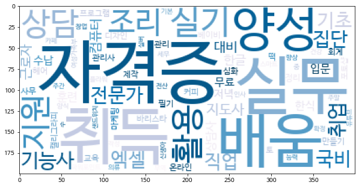

```python
from wordcloud import WordCloud
# from PIL import Image

wordcloud = WordCloud(font_path='NanumBarunGothic',
                      colormap="PuBu",
                      background_color="white")

wc=wordcloud.generate_from_frequencies(rank_txt)
plt.figure(figsize=(10,15))
plt.imshow(wc)
```

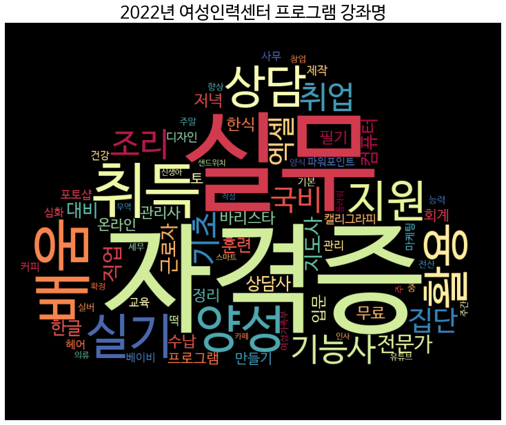

```python
from wordcloud import WordCloud
from PIL import Image           # 이미지 가져오는 실행어

mask = np.array(Image.open('/content/cloud.png'))

# 가로, 세로, 색깔, 폰트 정보 등 지정
wordcloud = WordCloud(width = 800, height = 800,
                      colormap = "Spectral", #"PiYG", "Spectral"
                      background_color = 'black',
                      mask = mask,       # 이미지 대입
                      font_path='NanumBarunGothic').generate_from_frequencies(rank_txt)

# wc=wordcloud.generate_from_frequencies(rank_txt)

# figure 정보 설정
plt.figure(figsize = (10, 15), facecolor = None)
plt.imshow(wordcloud)

plt.title("2022년 여성인력센터 프로그램 강좌명", size = 25)

# 축 이름을 지우는 등의 설정
plt.axis("off")
plt.tight_layout(pad = 0)
```

##### 상위 20개 막대그래프

```python
# 사전형식이기 때문에
# 키와 데이터 값으로 나누어 리스트로 담기

key = rank_txt.keys()
values = rank_txt.values()
```

```python
# 이름 지정해서 사전으로
dic = {'단어' : key, '빈도수' : values}
```

```python
# 데이터 프레임으로 변환
counter = pd.DataFrame(dic)
counter
```

|  | 단어 | 빈도수 |
| --- | --- | --- |
| 0 | 컴퓨터 | 31 |
| 1 | 기초 | 41 |
| 2 | 작성 | 11 |
| 3 | 전문가 | 40 |
| 4 | 헤어 | 17 |
| ... | ... | ... |
| 73 | 실버 | 14 |
| 74 | 제작 | 19 |
| 75 | 근로자 | 32 |
| 76 | 신생아 | 11 |
| 77 | 플라워 | 12 |

78 rows × 2 columns

```python
# 내림정렬
counter.sort_values(by = '빈도수',ascending = False, inplace = True)
```

```python
count_20 = counter.head(20)
count_20.info()
```

```
<class 'pandas.core.frame.DataFrame'>
Int64Index: 20 entries, 5 to 75
Data columns (total 2 columns):
 #   Column  Non-Null Count  Dtype
---  ------  --------------  -----
 0   단어      20 non-null     object
 1   빈도수     20 non-null     int64
dtypes: int64(1), object(1)
memory usage: 480.0+ bytes
```

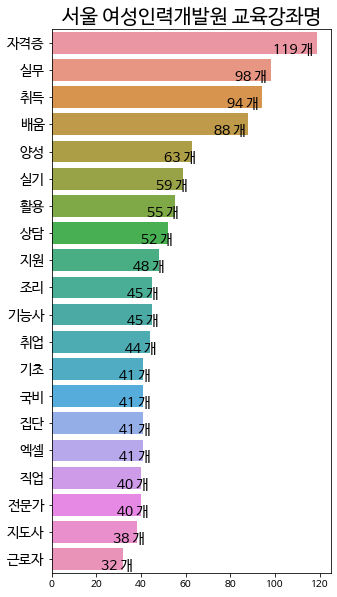

```python
fig, ax = plt.subplots(figsize = (5, 10))

sns.barplot(data = count_20,
            x = "빈도수", y= "단어",
            ci = None)

plt.title('서울 여성인력개발원 교육강좌명', fontsize = 20)
plt.xlabel('')
plt.ylabel('')
plt.yticks(fontsize = 14)


# 값 가져와서 -> 텍스트 추가하기
# ax.patches >> 그래프 안의 막대들
for p in ax.patches:
    ax.text(p.get_x() + (p.get_width()/11*10) ,   # 가로 위치
            p.get_y() + p.get_height(),   # 세로 위치

            f"{round(p.get_width())} 개",     # 값(막대의 가로길이를 계산) + 표시방법(소수 둘째자리까지)

            ha = 'center',  # 좌우정렬 중간으로
            fontsize = 14)  # 글자 크기

plt.show()
```

### 4. 강서구내 뜨는 산업 or 취업 직종

- 서울시 사업체현황 종사자수(산업대분류별 동별 성별) 통계 – 강서구 발전 산업들?
- 취업전망이 좋은 직업? – 중장기 인력수급 전망 2020-2030
- 서울시 직업유형별 취업인구(구별) 통계 – 강서구 여성 취업 직종 파악? (문제점 -> 2020, 2015, 2010 자료밖에 없음.)

#### 서울시 직업유형별 취업인구(구별)

```python
filename = '/content/서울시 직업유형별 취업인구(구별) 통계.xlsx'
```

```python
#csv파일 읽어오기
# df = pd.read_csv(filename, encoding='cp949')
df6 = pd.read_excel(filename)  #엑셀파일
```

```python
df6.shape  # 크기 확인
```

```
(572, 6)
```

```python
df6.isna().sum()  # 결측값 확인
```

```
기간      0
행정구역    0
직업유형    0
합계      0
남자      0
여자      0
dtype: int64
```

```python
df6.info()  # 데이터 전체적인 파악
```

```
<class 'pandas.core.frame.DataFrame'>
RangeIndex: 572 entries, 0 to 571
Data columns (total 6 columns):
 #   Column  Non-Null Count  Dtype
---  ------  --------------  -----
 0   기간      572 non-null    int64
 1   행정구역    572 non-null    object
 2   직업유형    572 non-null    object
 3   합계      572 non-null    int64
 4   남자      572 non-null    int64
 5   여자      572 non-null    object
dtypes: int64(3), object(3)
memory usage: 26.9+ KB
```

```python
df6
```

```python
df6 = df6[df6['행정구역'] == '강서구']
```

```python
del df6['행정구역']
```

```python
df6.loc[df6['여자'] == '-','여자'] = 0
```

```python
df6['여자'].astype(int)
```

```
176    121121
177      1351
178     33255
179     30433
180     20033
181     18383
182       128
183      3793
184      2351
185     11386
186         8
462    140763
463       395
464     35375
465     41622
466     25021
467     19810
468       189
469      3854
470      2370
471     12127
472         0
Name: 여자, dtype: int64
```

```python
# 데이터 행렬바꾸기 (R에서의 reshape2 패키지와 동일)
df6 = pd.melt(df6, id_vars = ['기간', '직업유형'])
```

```python
df6.columns = ['기간', '직업유형', '성별', '값']
```

```python
job = df6[(df6['성별'] == '여자') & (df6['직업유형'] != '소계')]
```

```python
job.head()
```

|  | 기간 | 직업유형 | 성별 | 값 |
| --- | --- | --- | --- | --- |
| 45 | 2015 | 관리자 | 여자 | 1351 |
| 46 | 2015 | 전문가 및 관련종사자 | 여자 | 33255 |
| 47 | 2015 | 사무종사자 | 여자 | 30433 |
| 48 | 2015 | 서비스종사자 | 여자 | 20033 |
| 49 | 2015 | 판매종사자 | 여자 | 18383 |

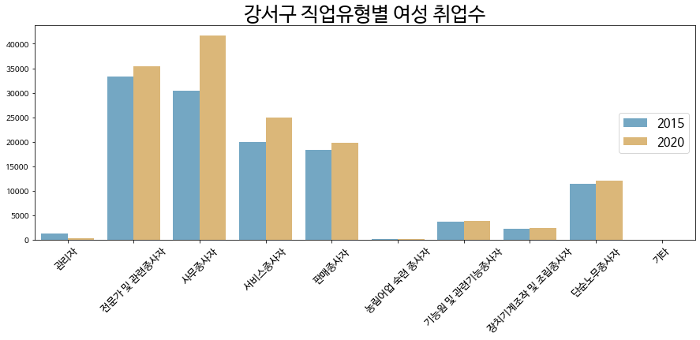

```python
plt.subplots( figsize=(15,5) )

g = sns.barplot(x = '직업유형', y = '값', hue = '기간', data = job,
                ci = None, palette = "colorblind",  alpha = .6)
# 제목
plt.title('강서구 직업유형별 여성 취업수', fontsize = 25)

# 축명
plt.xlabel('')
plt.ylabel('')

# x축 눈금명
plt.xticks(fontsize = 13, rotation = 45)

# 범례 표시
plt.legend(loc='center right', bbox_to_anchor=(1, 0.5), fontsize= 15)
```

#### 서울시 산업체현황 종사자수 (산업대분류별, 동별, 성별) 통계

```python
filename = '/content/서울시 사업체현황 종사자수(산업대분류별동별성별) 통계.xlsx'
```

```python
#csv파일 읽어오기
#df = pd.read_csv(filename, encoding='cp949')
df7 = pd.read_excel(filename, na_values = ['-'])  #엑셀파일
                             # NA 처리 문자 지정
```

```python
df7.shape  # 크기 확인
```

```
(1350, 44)
```

```python
df7.isna().sum()  # 결측값 확인
```

```
기간                               0
자치구                              0
동                                0
합계                               0
합계.1                             0
합계.2                             0
농업 임업 및 어업                    1233
농업 임업 및 어업.1                  1266
광업                            1264
광업.1                          1309
제조업                              0
제조업.1                            1
전기 가스 증기 및 공기조절 공급업            990
전기 가스 증기 및 공기조절 공급업.1         1107
수도 하수 및 폐기물 처리 원료 재생업          573
수도 하수 및 폐기물 처리 원료 재생업.1        731
건설업                              5
건설업.1                           11
도매 및 소매업                         0
도매 및 소매업.1                       0
운수 및 창고업                         1
운수 및 창고업.1                       8
숙박 및 음식점업                        3
숙박 및 음식점업.1                      3
정보통신업                           25
정보통신업.1                         54
금융 및 보험업                         8
금융 및 보험업.1                      13
부동산업                             3
부동산업.1                           3
전문 과학 및 기술 서비스업                  3
전문 과학 및 기술 서비스업.1               16
사업시설 관리 사업 지원 및 임대 서비스업          9
사업시설 관리 사업 지원 및 임대 서비스업.1       23
공공행정 국방 및 사회보장 행정                4
공공행정 국방 및 사회보장 행정.1              4
교육 서비스업                          2
교육 서비스업.1                        2
보건업 및 사회복지 서비스업                  2
보건업 및 사회복지 서비스업.1                2
예술 스포츠 및 여가관련 서비스업               4
예술 스포츠 및 여가관련 서비스업.1             5
 협회 및 단체 수리 및 기타 개인 서비스업         0
 협회 및 단체 수리 및 기타 개인 서비스업.1       2
dtype: int64
```

```python
df7.info()  # 데이터 전체적인 파악
```

```
<class 'pandas.core.frame.DataFrame'>
RangeIndex: 1350 entries, 0 to 1349
Data columns (total 44 columns):
 #   Column                      Non-Null Count  Dtype
---  ------                      --------------  -----
 0   기간                          1350 non-null   int64
 1   자치구                         1350 non-null   object
 2   동                           1350 non-null   object
 3   합계                          1350 non-null   int64
 4   합계.1                        1350 non-null   int64
 5   합계.2                        1350 non-null   int64
 6   농업 임업 및 어업                  117 non-null    float64
 7   농업 임업 및 어업.1                84 non-null     float64
 8   광업                          86 non-null     float64
 9   광업.1                        41 non-null     float64
```

[output cut: 36 more lines]

- 컬럼명 해석
1. 합계
   - 합계 - 사업체수
   - 합계.1 - 총종사자수
   - 합계.2 - 여성종사자수

```python
df7.head()
```

|  | 기간 | 자치구 | 동 | 합계 | 합계.1 | 합계.2 | 농업 임업 및 어업 | 농업 임업 및 어업.1 | 광업 | 광업.1 | ... | 공공행정 국방 및 사회보장 행정 | 공공행정 국방 및 사회보장 행정.1 | 교육 서비스업 | 교육 서비스업.1 | 보건업 및 사회복지 서비스업 | 보건업 및 사회복지 서비스업.1 | 예술 스포츠 및 여가관련 서비스업 | 예술 스포츠 및 여가관련 서비스업.1 | 협회 및 단체 수리 및 기타 개인 서비스업 | 협회 및 단체 수리 및 기타 개인 서비스업.1 |
| --- | --- | --- | --- | --- | --- | --- | --- | --- | --- | --- | --- | --- | --- | --- | --- | --- | --- | --- | --- | --- | --- |
| 0 | 2017 | 합계 | 합계 | 822863 | 5119913 | 2271763 | 469.0 | 88.0 | 66.0 | 8.0 | ... | 138150.0 | 49489.0 | 341732.0 | 210109.0 | 358563.0 | 284717.0 | 86452.0 | 39622.0 | 190963 | 96989.0 |
| 1 | 2017 | 종로구 | 소계 | 40490 | 268702 | 114602 | 30.0 | 10.0 | 10.0 | 2.0 | ... | 16504.0 | 4978.0 | 13317.0 | 7437.0 | 15954.0 | 11787.0 | 6198.0 | 2940.0 | 8275 | 3722.0 |
| 2 | 2017 | 종로구 | 사직동 | 3544 | 52489 | 21460 | 16.0 | 4.0 | NaN | NaN | ... | 7667.0 | 2548.0 | 898.0 | 549.0 | 764.0 | 588.0 | 1546.0 | 708.0 | 920 | 464.0 |
| 3 | 2017 | 종로구 | 삼청동 | 753 | 4507 | 2282 | NaN | NaN | NaN | NaN | ... | 1229.0 | 279.0 | 279.0 | 148.0 | 28.0 | 22.0 | 172.0 | 116.0 | 216 | 132.0 |
| 4 | 2017 | 종로구 | 부암동 | 567 | 4147 | 2010 | NaN | NaN | 5.0 | 1.0 | ... | 58.0 | 9.0 | 1543.0 | 832.0 | 153.0 | 129.0 | 73.0 | 46.0 | 806 | 227.0 |

5 rows × 44 columns

```python
df7 = df7.fillna(0)
```

```python
df7.iloc[:, 6:] = df7.iloc[:, 6:].astype(int)
```

```python
gang = df7[df7['자치구'] == '강서구']
```

```python
gang.head()
```

|  | 기간 | 자치구 | 동 | 합계 | 합계.1 | 합계.2 | 농업 임업 및 어업 | 농업 임업 및 어업.1 | 광업 | 광업.1 | ... | 공공행정 국방 및 사회보장 행정 | 공공행정 국방 및 사회보장 행정.1 | 교육 서비스업 | 교육 서비스업.1 | 보건업 및 사회복지 서비스업 | 보건업 및 사회복지 서비스업.1 | 예술 스포츠 및 여가관련 서비스업 | 예술 스포츠 및 여가관련 서비스업.1 | 협회 및 단체 수리 및 기타 개인 서비스업 | 협회 및 단체 수리 및 기타 개인 서비스업.1 |
| --- | --- | --- | --- | --- | --- | --- | --- | --- | --- | --- | --- | --- | --- | --- | --- | --- | --- | --- | --- | --- | --- |
| 256 | 2017 | 강서구 | 소계 | 36556 | 234394 | 104389 | 30 | 3 | 0 | 0 | ... | 3267 | 1180 | 13832 | 9361 | 17902 | 15031 | 3498 | 1679 | 9229 | 4467 |
| 257 | 2017 | 강서구 | 염창동 | 2126 | 16513 | 6594 | 0 | 0 | 0 | 0 | ... | 59 | 11 | 1055 | 787 | 1087 | 863 | 231 | 109 | 837 | 313 |
| 258 | 2017 | 강서구 | 등촌1동 | 1892 | 15709 | 6584 | 0 | 0 | 0 | 0 | ... | 448 | 97 | 385 | 279 | 931 | 820 | 201 | 78 | 882 | 240 |
| 259 | 2017 | 강서구 | 등촌2동 | 737 | 3766 | 1987 | 0 | 0 | 0 | 0 | ... | 124 | 41 | 634 | 388 | 328 | 268 | 86 | 53 | 259 | 95 |
| 260 | 2017 | 강서구 | 등촌3동 | 2657 | 23388 | 12190 | 0 | 0 | 0 | 0 | ... | 98 | 26 | 1835 | 1112 | 2416 | 2051 | 400 | 179 | 779 | 438 |

5 rows × 44 columns

```python
gang.info()
```

```
<class 'pandas.core.frame.DataFrame'>
Int64Index: 63 entries, 256 to 1176
Data columns (total 44 columns):
 #   Column                      Non-Null Count  Dtype
---  ------                      --------------  -----
 0   기간                          63 non-null     int64
 1   자치구                         63 non-null     object
 2   동                           63 non-null     object
 3   합계                          63 non-null     int64
 4   합계.1                        63 non-null     int64
 5   합계.2                        63 non-null     int64
 6   농업 임업 및 어업                  63 non-null     int64
 7   농업 임업 및 어업.1                63 non-null     int64
 8   광업                          63 non-null     int64
 9   광업.1                        63 non-null     int64
```

[output cut: 36 more lines]

```python
# 취업자수, 증가율 컬럼 나누기
idx = [x for x in range(6, 44, 2)]
id = [x for x in range(7, 44, 2)]
```

```python
# 기본 컬럼들 추가하기
for x in [0, 2]:
    idx.append(x)
    id.append(x)
print(idx)
print(id)
```

```
[6, 8, 10, 12, 14, 16, 18, 20, 22, 24, 26, 28, 30, 32, 34, 36, 38, 40, 42, 0, 2]
[7, 9, 11, 13, 15, 17, 19, 21, 23, 25, 27, 29, 31, 33, 35, 37, 39, 41, 43, 0, 2]
```

```python
total = gang.iloc[:, idx]
worker = gang.iloc[:, id]
```

```python
total = total[total['동'] == '소계']
worker = worker[worker['동'] == '소계']
```

```python
total.iloc[:, :-1]
```

|  | 농업 임업 및 어업 | 광업 | 제조업 | 전기 가스 증기 및 공기조절 공급업 | 수도 하수 및 폐기물 처리 원료 재생업 | 건설업 | 도매 및 소매업 | 운수 및 창고업 | 숙박 및 음식점업 | 정보통신업 | 금융 및 보험업 | 부동산업 | 전문 과학 및 기술 서비스업 | 사업시설 관리 사업 지원 및 임대 서비스업 | 공공행정 국방 및 사회보장 행정 | 교육 서비스업 | 보건업 및 사회복지 서비스업 | 예술 스포츠 및 여가관련 서비스업 | 협회 및 단체 수리 및 기타 개인 서비스업 | 기간 |
| --- | --- | --- | --- | --- | --- | --- | --- | --- | --- | --- | --- | --- | --- | --- | --- | --- | --- | --- | --- | --- |
| 256 | 30 | 0 | 7027 | 426 | 639 | 13334 | 34665 | 53820 | 20057 | 11196 | 3976 | 7006 | 17291 | 17199 | 3267 | 13832 | 17902 | 3498 | 9229 | 2017 |
| 706 | 26 | 1 | 7311 | 466 | 673 | 14875 | 37641 | 52138 | 21475 | 11108 | 3996 | 7464 | 23116 | 17365 | 3474 | 14257 | 19576 | 3851 | 9391 | 2018 |
| 1156 | 29 | 1 | 7317 | 515 | 696 | 15605 | 37437 | 50974 | 22192 | 11620 | 4682 | 8781 | 25339 | 17798 | 3971 | 14191 | 22593 | 4083 | 9670 | 2019 |

```python
worker.columns = total.columns
```

```python
# 데이터 행렬바꾸기 (R에서의 reshape2 패키지와 동일)
total = pd.melt(total.iloc[:, :-1], id_vars = ['기간'])
worker = pd.melt(worker.iloc[:, :-1], id_vars = ['기간'])
```

```python
total.columns = ['기간', '구분', '값']
worker.columns = ['기간', '구분', '값']
```

```python
# 기간의 값을 '...년'으로 바꾸기 위해 카테고리형으로 바꾸기
total['기간'] = total['기간'].astype('category')
worker['기간'] = worker['기간'].astype('category')
```

```python
# '기간의 값을 '...년'으로 바꾸기
total['기간'].cat.categories = ['2017년', '2018년', '2019년']
worker['기간'].cat.categories = ['2017년', '2018년', '2019년']
```

```python
total.sort_values(by = ['기간', '값'], ascending = [False, False], inplace = True)
worker.sort_values(by = ['기간', '값'], ascending = [False, False], inplace = True)
```

##### 강서구 연도별 산업체 현황

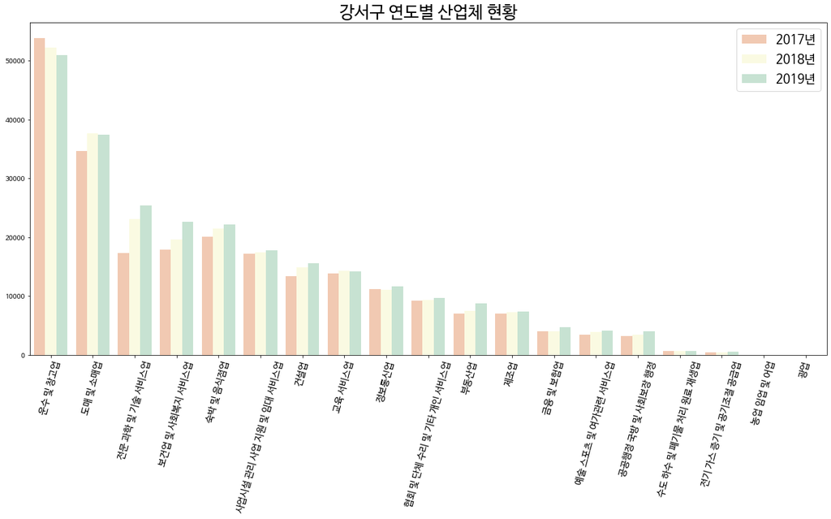

```python
fig = plt.figure(figsize = (21, 9))   # 그래프 화면 크기

g = sns.barplot(x = '구분', y = '값', hue= '기간', data = total, ci = None, palette = "Spectral", alpha = 0.5)

# 제목
plt.title('강서구 연도별 산업체 현황', fontsize= 25)

# 축제목
plt.xlabel('')
plt.ylabel('')

# x눈금 이름
plt.xticks(fontsize = 14, rotation = 75)

# 범례 위치
plt.legend(loc='upper right', fontsize= 18)

plt.show()
```

##### 강서구 연도별 여성종사자

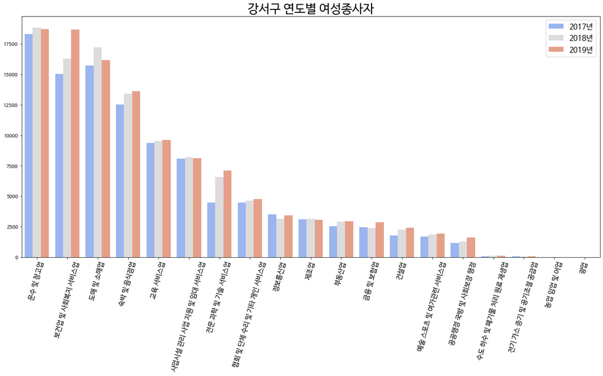

```python
fig = plt.figure(figsize = (21, 9))   # 그래프 화면 크기

g = sns.barplot(x = '구분', y = '값', hue= '기간', data = worker, ci = None, palette = "coolwarm") # , alpha = 0.8)  # "Spectral"


# 제목
plt.title('강서구 연도별 여성종사자', fontsize= 25)

# 축제목
plt.xlabel('')
plt.ylabel('')

# x눈금 이름
plt.xticks(fontsize = 14, rotation = 75)

# 범례 위치
plt.legend(loc='upper right', fontsize= 15) # , bbox_to_anchor=(1, 0.5)

plt.show()
```

#### 취업전망이 좋은 직업

- 중장기 인력수급 전망(2020 - 2030)

##### 취업자 증가 속도가 빠른 직업

```python
filename = '/content/취업자 증가 속도가 빠른 직업(세분류).xlsx'
```

```python
#csv파일 읽어오기
# df = pd.read_csv(filename, encoding='cp949')
df8 = pd.read_excel(filename)  #엑셀파일
```

```python
df8.shape  # 크기 확인
```

```
(22, 17)
```

```python
df8.isna().sum()  # 결측값 확인
```

```
직  업  명        1
취업자 수          0
Unnamed: 2     0
Unnamed: 3     0
Unnamed: 4     0
증감             0
Unnamed: 6     0
Unnamed: 7     0
Unnamed: 8     0
연평균 증가율        0
Unnamed: 10    0
Unnamed: 11    0
Unnamed: 12    0
비중             0
Unnamed: 14    0
Unnamed: 15    0
Unnamed: 16    0
dtype: int64
```

```python
df8.info()  # 데이터 전체적인 파악
```

```
<class 'pandas.core.frame.DataFrame'>
RangeIndex: 22 entries, 0 to 21
Data columns (total 17 columns):
 #   Column       Non-Null Count  Dtype
---  ------       --------------  -----
 0   직  업  명      21 non-null     object
 1   취업자 수        22 non-null     float64
 2   Unnamed: 2   22 non-null     float64
 3   Unnamed: 3   22 non-null     float64
 4   Unnamed: 4   22 non-null     float64
 5   증감           22 non-null     object
 6   Unnamed: 6   22 non-null     object
 7   Unnamed: 7   22 non-null     object
 8   Unnamed: 8   22 non-null     object
 9   연평균 증가율      22 non-null     object
 10  Unnamed: 10  22 non-null     object
 11  Unnamed: 11  22 non-null     object
 12  Unnamed: 12  22 non-null     object
 13  비중           22 non-null     float64
 14  Unnamed: 14  22 non-null     float64
 15  Unnamed: 15  22 non-null     float64
 16  Unnamed: 16  22 non-null     float64
dtypes: float64(8), object(9)
memory usage: 3.0+ KB
```

```python
df8.head()
```

|  | 직 업 명 | 취업자 수 | Unnamed: 2 | Unnamed: 3 | Unnamed: 4 | 증감 | Unnamed: 6 | Unnamed: 7 | Unnamed: 8 | 연평균 증가율 | Unnamed: 10 | Unnamed: 11 | Unnamed: 12 | 비중 | Unnamed: 14 | Unnamed: 15 | Unnamed: 16 |
| --- | --- | --- | --- | --- | --- | --- | --- | --- | --- | --- | --- | --- | --- | --- | --- | --- | --- |
| 0 | NaN | 2015.0 | 2020.0 | 2025.0 | 2030.0 | 2015\n~2020 | 2020\n~2025 | 2025\n~2030 | 2020\n~2030 | 2015\n~2030 | 2020\n~2025 | 2025\n~2030 | 2020\n~2030 | 2015.0 | 2020.0 | 2025.0 | 2030.0 |
| 1 | 전 체 | 26177.7 | 26904.3 | 27995.3 | 27888.4 | 726.6 | 1091 | -106.8 | 984.1 | 0.5 | 0.8 | -0.1 | 0.4 | 100.0 | 100.0 | 100.0 | 100.0 |
| 2 | 돌봄 서비스 종사원 | 264.2 | 430.0 | 598.4 | 756.3 | 165.8 | 168.5 | 157.8 | 326.3 | 10.2 | 6.8 | 4.8 | 5.8 | 75.2 | 77.4 | 80.5 | 83.6 |
| 3 | 데이터 전문가 | 5.9 | 18.8 | 25.8 | 32.5 | 12.8 | 7.1 | 6.6 | 13.7 | 25.9 | 6.6 | 4.7 | 5.6 | 19.3 | 43.9 | 49.0 | 54.3 |
| 4 | 시스템 소프트웨어 개발자 | 78.6 | 111.4 | 140.4 | 157.9 | 32.9 | 29 | 17.4 | 46.4 | 7.2 | 4.7 | 2.4 | 3.5 | 29.4 | 33.3 | 35.0 | 36.4 |

```python
# 취업자 수
employ = df8.iloc[2:, :5]

# 연평균 증가율
high = df8.iloc[2:, [0, 9, 10, 11, 12]]
```

```python
employ.columns = ['직업명', '2015년', '2020년', '2025년', '2030년']
high.columns = ['직업명', '2015년 ~ 2030년', '2020년 ~ 2025년', '2025년 ~ 2030년', '2020년 ~ 2030년']
```

```python
# 데이터 행렬바꾸기 (R에서의 reshape2 패키지와 동일)
employ = pd.melt(employ, id_vars = ['직업명'])
high = pd.melt(high, id_vars = ['직업명'])
```

```python
employ.columns = ['직업명', '시기', '값']
high.columns = ['직업명', '시기', '값']
```

```python
high['값'] = high['값'].astype('float64')
```

- 취업자 그래프

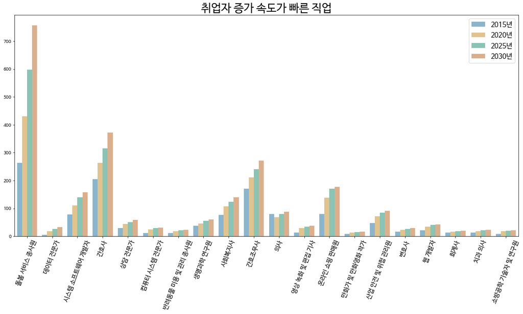

```python
fig = plt.figure(figsize = (20, 9))   # 그래프 화면 크기

g = sns.barplot(x = '직업명', y = '값', hue= '시기', data = employ, ci = None, palette = "colorblind", alpha = 0.5)  # "Spectral" , "coolwarm"

# 제목
plt.title('취업자 증가 속도가 빠른 직업', fontsize= 25)

# 축제목
plt.xlabel('')
plt.ylabel('')

# x눈금 이름
plt.xticks(fontsize = 14, rotation = 70)

# 범례 위치
plt.legend(loc='upper right', fontsize= 15)

plt.show()
```

- 연평균 증가율

```python
high = high[(high['시기'] == '2020년 ~ 2025년') | (high['시기'] == '2020년 ~ 2030년')]
```

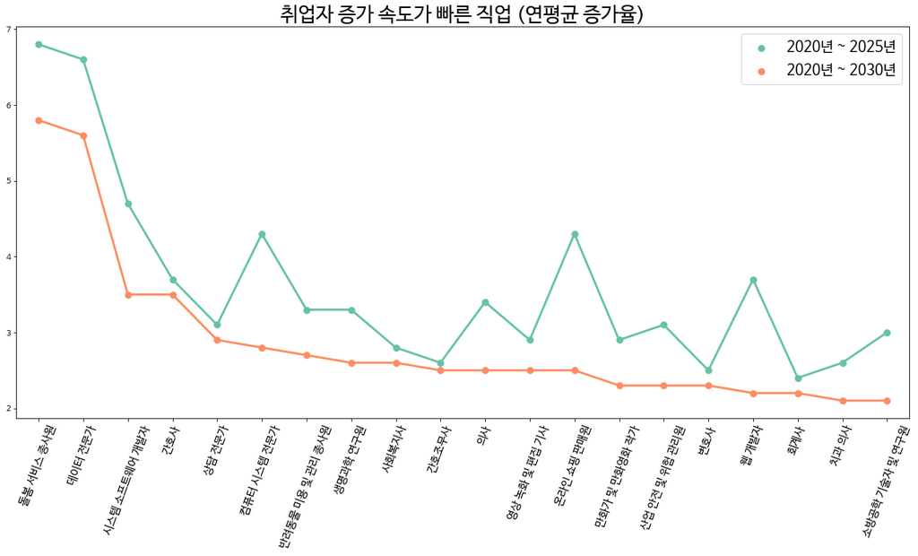

```python
fig = plt.figure(figsize = (20, 9))   # 그래프 화면 크기

g = sns.pointplot(x = '직업명', y = '값', hue= '시기', data = high, ci = None, palette = "Set2") # , alpha = 0.4)  # "Spectral" , "coolwarm", "colorblind"

# 제목
plt.title('취업자 증가 속도가 빠른 직업 (연평균 증가율)', fontsize= 25)

# 축제목
plt.xlabel('')
plt.ylabel('')

# x눈금 이름
plt.xticks(fontsize = 14, rotation = 70)

# 범례 위치
plt.legend(loc='upper right', fontsize= 18) # , bbox_to_anchor=(1, 0.5)

plt.show()
```

##### 취업자 증가 속도가 빠른 산업

```python
filename = '/content/취업자 증가 속도가 빠른 산업(소분류).xlsx'
```

```python
#csv파일 읽어오기
# df = pd.read_csv(filename, encoding='cp949')
df9 = pd.read_excel(filename)  #엑셀파일
```

```python
df9.shape  # 크기 확인
```

```
(32, 17)
```

```python
df9.isna().sum()  # 결측값 확인
```

```
산  업  명        1
취업자 수          0
Unnamed: 2     0
Unnamed: 3     0
Unnamed: 4     0
증감             0
Unnamed: 6     0
Unnamed: 7     0
Unnamed: 8     0
연평균 증가율        0
Unnamed: 10    0
Unnamed: 11    0
Unnamed: 12    0
비중             0
Unnamed: 14    0
Unnamed: 15    0
Unnamed: 16    0
dtype: int64
```

```python
df9.info()  # 데이터 전체적인 파악
```

```
<class 'pandas.core.frame.DataFrame'>
RangeIndex: 32 entries, 0 to 31
Data columns (total 17 columns):
 #   Column       Non-Null Count  Dtype
---  ------       --------------  -----
 0   산  업  명      31 non-null     object
 1   취업자 수        32 non-null     float64
 2   Unnamed: 2   32 non-null     float64
 3   Unnamed: 3   32 non-null     float64
 4   Unnamed: 4   32 non-null     float64
 5   증감           32 non-null     object
 6   Unnamed: 6   32 non-null     object
 7   Unnamed: 7   32 non-null     object
 8   Unnamed: 8   32 non-null     object
 9   연평균 증가율      32 non-null     object
 10  Unnamed: 10  32 non-null     object
 11  Unnamed: 11  32 non-null     object
 12  Unnamed: 12  32 non-null     object
 13  비중           32 non-null     float64
 14  Unnamed: 14  32 non-null     float64
 15  Unnamed: 15  32 non-null     float64
 16  Unnamed: 16  32 non-null     float64
dtypes: float64(8), object(9)
memory usage: 4.4+ KB
```

```python
df9.head()
```

|  | 산 업 명 | 취업자 수 | Unnamed: 2 | Unnamed: 3 | Unnamed: 4 | 증감 | Unnamed: 6 | Unnamed: 7 | Unnamed: 8 | 연평균 증가율 | Unnamed: 10 | Unnamed: 11 | Unnamed: 12 | 비중 | Unnamed: 14 | Unnamed: 15 | Unnamed: 16 |
| --- | --- | --- | --- | --- | --- | --- | --- | --- | --- | --- | --- | --- | --- | --- | --- | --- | --- |
| 0 | NaN | 2015.0 | 2020.0 | 2025.0 | 2030.0 | 2015\n~2020 | 2020\n~2025 | 2025\n~2030 | 2020\n~2030 | 2015\n~2020 | 2020\n~2025 | 2025\n~2030 | 2020\n~2030 | 2015.0 | 2020.0 | 2025.0 | 2030.0 |
| 1 | 전 체 | 26177.7 | 26904.3 | 27995.3 | 27888.4 | 726.6 | 1091 | -106.8 | 984.1 | 0.5 | 0.8 | -0.1 | 0.4 | 100.0 | 100.0 | 100.0 | 100.0 |
| 2 | 비거주 복지시설 운영업 | 714.4 | 1111.4 | 1365.1 | 1593.5 | 397 | 253.7 | 228.5 | 482.2 | 9.2 | 4.2 | 3.1 | 3.7 | 83.0 | 87.3 | 88.4 | 89.1 |
| 3 | 영상 및 음향기기 제조업 | 33.0 | 26.3 | 35.1 | 36.9 | -6.7 | 8.9 | 1.7 | 10.6 | -4.5 | 6 | 1 | 3.4 | 6.3 | 5.1 | 6.0 | 6.1 |
| 4 | 자료처리, 호스팅, 포털 및 기타 인터넷 정보매개 서비스업 | 24.8 | 35.9 | 50.1 | 49.7 | 11.1 | 14.2 | -0.4 | 13.8 | 7.6 | 6.9 | -0.2 | 3.3 | 67.9 | 60.2 | 64.3 | 64.3 |

```python
# 취업자 수
indust = df9.iloc[2:, :5]

# 연평균 증가율
grow = df9.iloc[2:, [0, 9, 10, 11, 12]]
```

```python
indust.columns = ['산업명', '2015년', '2020년', '2025년', '2030년']
grow.columns = ['산업명', '2015년 ~ 2020년', '2020년 ~ 2025년', '2025년 ~ 2030년', '2020년 ~ 2030년']
```

```python
# 데이터 행렬바꾸기 (R에서의 reshape2 패키지와 동일)
indust = pd.melt(indust, id_vars = ['산업명'])
grow = pd.melt(grow, id_vars = ['산업명'])
```

```python
indust.columns = ['산업명', '시기', '값']
grow.columns = ['산업명', '시기', '값']
```

```python
grow['값'] = grow['값'].astype('float64')
```

- 취업자 그래프

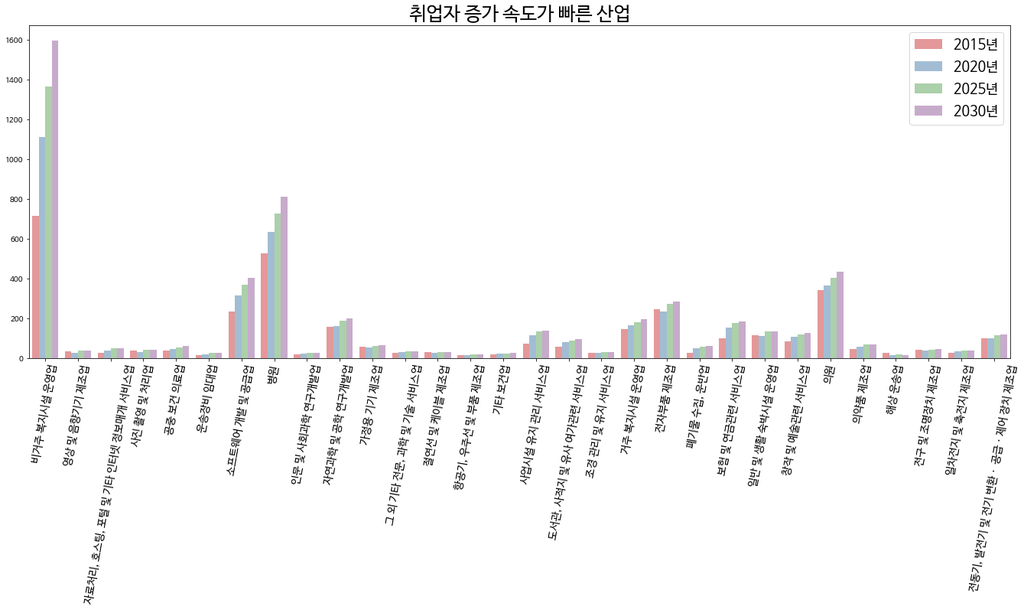

```python
fig = plt.figure(figsize = (23, 8))   # 그래프 화면 크기

g = sns.barplot(x = '산업명', y = '값', hue= '시기', data = indust, ci = None, palette = "Set1", alpha = 0.5)  # "Spectral" , "coolwarm"

# 제목
plt.title('취업자 증가 속도가 빠른 산업', fontsize= 25)

# 축제목
plt.xlabel('')
plt.ylabel('')

# x눈금 이름
plt.xticks(fontsize = 14, rotation = 80)

# 범례 위치
plt.legend(loc='upper right', fontsize= 18) # , bbox_to_anchor=(1, 0.5)

plt.show()
```

- 연평균 증가율

[figure not shown]

```python
fig = plt.figure(figsize = (9, 14))   # 그래프 화면 크기

sns.scatterplot(y = "산업명", x = "값", hue = '시기',
                data = grow, size = "값",
                palette = 'spring',
                legend = True,   # 버블의 크기 범례를 나타남
                sizes = (20, 400),  # 버블의 크기
                alpha = 0.5)  # 버블의 투명도


# 제목
plt.title('취업자 증가 속도가 빠른 산업 (연평균 증가율)', fontsize= 20)

# 축제목
plt.xlabel('')
plt.ylabel('')

# x눈금 이름
plt.yticks(fontsize = 14)

# 범례 위치
plt.legend(loc='center right', bbox_to_anchor=(1.35, 0.5), fontsize= 14)

plt.show()
```

- 2015 ~ 2020년에 마이너스 값이 존재해서 그래프가 이쁘지 않음
- 2020년 ~ 2025년, 2020년 ~ 2030년 증가율만 가지고 그래프

```python
grow = grow[(grow['시기'] == '2020년 ~ 2025년') | (grow['시기'] == '2020년 ~ 2030년')]
```

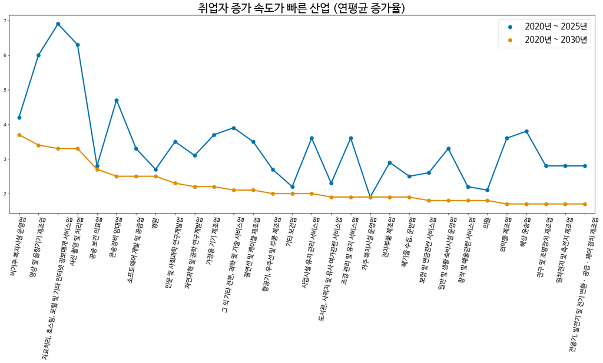

```python
fig = plt.figure(figsize = (23, 8))   # 그래프 화면 크기

g = sns.pointplot(x = '산업명', y = '값', hue= '시기', data = grow,
                  ci = None, palette = "colorblind") # , alpha = 0.4)  # "Set2" , "coolwarm", "Spectral"

# 제목
plt.title('취업자 증가 속도가 빠른 산업 (연평균 증가율)', fontsize= 25)

# 축제목
plt.xlabel('')
plt.ylabel('')

# x눈금 이름
plt.xticks(fontsize = 14, rotation = 80)

# 범례 위치
plt.legend(loc='upper right', fontsize= 18) # , bbox_to_anchor=(1, 0.5)

plt.show()
```

```python
!jupyter nbconvert --to html "/content/drive/MyDrive/Colab Notebooks/TEST/notebook_test.ipynb"
```